# Claude에서 비전을 사용하는 모범 사례

비전은 Claude와 상호작용하는 새로운 방식을 열어 줍니다. 이미지에서 최고의 성능을 얻기 위한 몇 가지 팁을 정리했습니다. 본격적으로 들어가기 전에, 노트북 실행에 필요한 코드부터 준비하겠습니다.

```python
%pip install anthropic IPython
```

```python
import base64

from anthropic import Anthropic
from IPython.display import Image

client = Anthropic()
MODEL_NAME = "claude-opus-4-1"


def get_base64_encoded_image(image_path):
    with open(image_path, "rb") as image_file:
        binary_data = image_file.read()
        base_64_encoded_data = base64.b64encode(binary_data)
        base64_string = base_64_encoded_data.decode("utf-8")
        return base64_string
```

## 전통적 기법을 멀티모달에 적용하기

역할 부여 같은 전통적인 프롬프트 엔지니어링 기법으로 환각 문제를 고칠 수 있습니다. 예를 보겠습니다:

이 이미지에서 개가 몇 마리인지 Claude에 세어 달라고 해 보겠습니다:

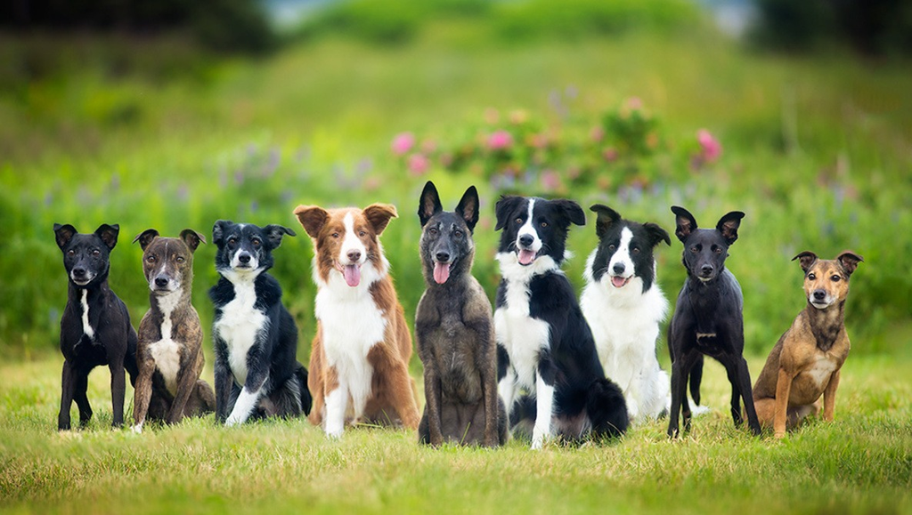

```python
Image(filename="../images/best_practices/nine_dogs.jpg")
```

```python
message_list = [
    {
        "role": "user",
        "content": [
            {
                "type": "image",
                "source": {
                    "type": "base64",
                    "media_type": "image/jpeg",
                    "data": get_base64_encoded_image("../images/best_practices/nine_dogs.jpg"),
                },
            },
            {"type": "text", "text": "How many dogs are in this picture?"},
        ],
    }
]

response = client.messages.create(model=MODEL_NAME, max_tokens=2048, messages=message_list)
print(response.content[0].text)
```

[output not shown]

개는 9마리뿐인데 Claude는 10마리라고 합니다! 프롬프트 엔지니어링을 조금 적용해 다시 시도해 보겠습니다.

```python
message_list = [
    {
        "role": "user",
        "content": [
            {
                "type": "image",
                "source": {
                    "type": "base64",
                    "media_type": "image/jpeg",
                    "data": get_base64_encoded_image("../images/best_practices/nine_dogs.jpg"),
                },
            },
            {
                "type": "text",
                "text": "You have perfect vision and pay great attention to detail which makes you an expert at counting objects in images. How many dogs are in this picture? Before providing the answer in <answer> tags, think step by step in <thinking> tags and analyze every part of the image.",
            },
        ],
    }
]

response = client.messages.create(model=MODEL_NAME, max_tokens=2048, messages=message_list)
print(response.content[0].text)
```

```
<thinking>
To accurately count the number of dogs in this image, I'll visually scan the image from left to right, focusing on each individual dog.

Starting on the left side, I see two black dogs standing next to each other. Moving to the right, there's a white and gray dog, then a brown and white dog, then a predominantly black dog with white markings.

Continuing to the right, I see a mostly black dog, then a black and white border collie type dog, then another dog with black and white fur.

Scanning the remaining right portion of the image, I see one more brown and white dog.

After carefully examining each dog in the photo, it appears I have accounted for all the dogs present.
</thinking>

<answer>There are 9 dogs total in this image of a diverse group of dogs sitting together in grass with some flowers in the background.</answer>
```

좋습니다! 프롬프트에 약간의 엔지니어링을 적용하자 Claude가 개가 9마리라고 정확히 셉니다.

## 시각적 프롬프팅

이미지를 입력으로 쓸 수 있게 되면서 프롬프트를 이미지 안에 담을 수도 있게 되었습니다. 몇 가지 예를 살펴보겠습니다.

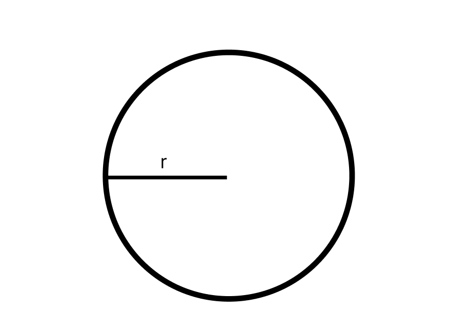

```python
Image(filename="../images/best_practices/circle.png")
```

```python
message_list = [
    {
        "role": "user",
        "content": [
            {
                "type": "image",
                "source": {
                    "type": "base64",
                    "media_type": "image/png",
                    "data": get_base64_encoded_image("../images/best_practices/circle.png"),
                },
            },
        ],
    }
]

response = client.messages.create(model=MODEL_NAME, max_tokens=2048, messages=message_list)
print(response.content[0].text)
```

```
The image shows a simple black circle outline on a white background. Inside the circle, there is a straight horizontal line segment that does not touch the circle's edges. The circle and line are both drawn with thin, black strokes, giving the appearance of a basic geometric diagram or symbol.
```

보시다시피 질문을 주지 않았기 때문에 Claude는 이미지를 설명하려 했습니다. 이번에는 이미지에 질문을 넣어 다시 전달해 보겠습니다.

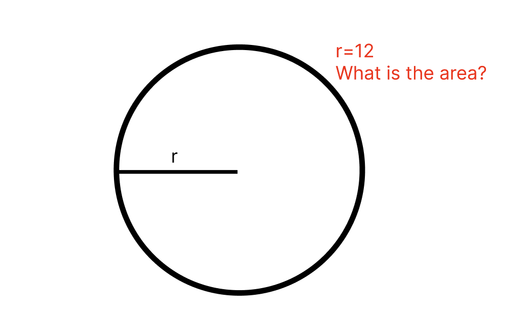

```python
Image(filename="../images/best_practices/labeled_circle.png")
```

```python
message_list = [
    {
        "role": "user",
        "content": [
            {
                "type": "image",
                "source": {
                    "type": "base64",
                    "media_type": "image/png",
                    "data": get_base64_encoded_image("../images/best_practices/labeled_circle.png"),
                },
            },
        ],
    }
]

response = client.messages.create(model=MODEL_NAME, max_tokens=2048, messages=message_list)
print(response.content[0].text)
```

```
The area of the circle is πr^2, where r is the radius of the circle. The question states that the radius is 12, so the area would be π(12)^2 = 144π square units.
```

이미지의 특정 부분을 강조 표시하고 그것에 대해 질문할 수도 있습니다.

이 두 숫자의 차이는 무엇일까요?

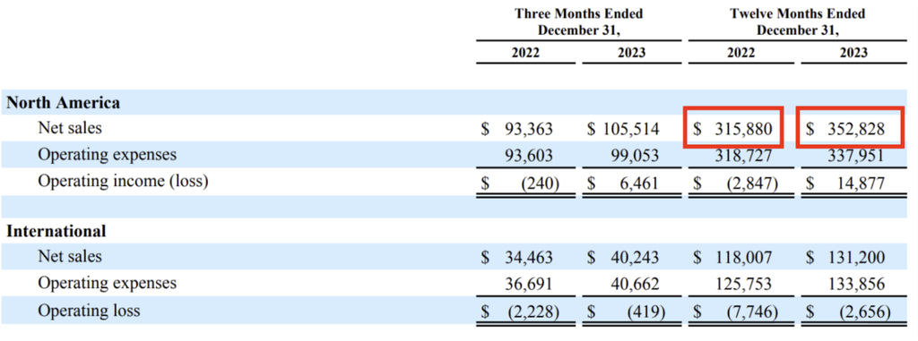

```python
Image(filename="../images/best_practices/table.png")
```

```python
message_list = [
    {
        "role": "user",
        "content": [
            {
                "type": "image",
                "source": {
                    "type": "base64",
                    "media_type": "image/png",
                    "data": get_base64_encoded_image("../images/best_practices/table.png"),
                },
            },
            {"type": "text", "text": "What’s the difference between these two numbers?"},
        ],
    }
]

response = client.messages.create(model=MODEL_NAME, max_tokens=2048, messages=message_list)
print(response.content[0].text)
```

```
The difference between North America's net sales for the twelve months ended December 31, 2023 ($352,828) and December 31, 2022 ($315,880) is $36,948.
```

## 퓨샷 예시

프롬프트에 예시를 추가하면 시각 작업에서도 정확도가 올라갑니다. 속도계 사진을 읽어 달라고 Claude에 요청해 보겠습니다.

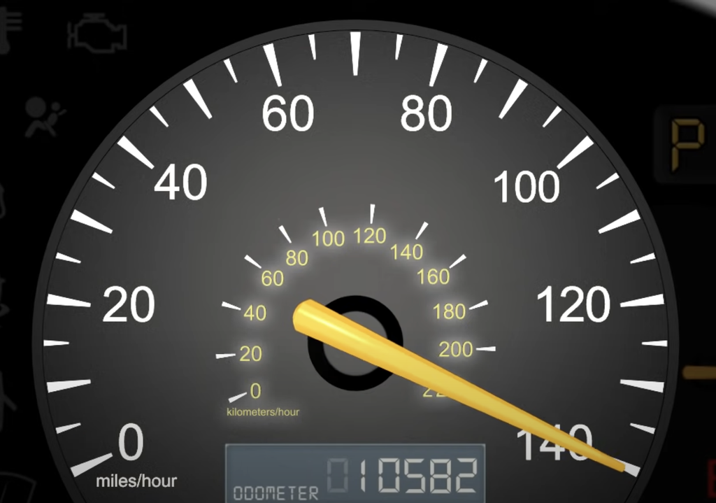

```python
Image(filename="../images/best_practices/140.png")
```

```python
message_list = [
    {
        "role": "user",
        "content": [
            {
                "type": "image",
                "source": {
                    "type": "base64",
                    "media_type": "image/png",
                    "data": get_base64_encoded_image("../images/best_practices/140.png"),
                },
            },
            {"type": "text", "text": "What speed am I going?"},
        ],
    }
]

response = client.messages.create(model=MODEL_NAME, max_tokens=2048, messages=message_list)
print(response.content[0].text)
```

```
The speedometer in the image is showing a speed of 140 kilometers/hour (or about 87 miles/hour).
```

Claude의 답이 어딘가 이상합니다. 시속 140마일이 아니라 140km라고 생각하고 있네요! 이번에는 프롬프트에 예시를 몇 개 추가해 다시 시도해 보겠습니다.

```python
message_list = [
    {
        "role": "user",
        "content": [
            {
                "type": "image",
                "source": {
                    "type": "base64",
                    "media_type": "image/png",
                    "data": get_base64_encoded_image("../images/best_practices/70.png"),
                },
            },
            {"type": "text", "text": "What speed am I going?"},
        ],
    },
    {
        "role": "assistant",
        "content": [{"type": "text", "text": "You are going 70 miles per hour."}],
    },
    {
        "role": "user",
        "content": [
            {
                "type": "image",
                "source": {
                    "type": "base64",
                    "media_type": "image/png",
                    "data": get_base64_encoded_image("../images/best_practices/100.png"),
                },
            },
            {"type": "text", "text": "What speed am I going?"},
        ],
    },
    {
        "role": "assistant",
        "content": [{"type": "text", "text": "You are going 100 miles per hour."}],
    },
    {
        "role": "user",
        "content": [
            {
                "type": "image",
                "source": {
                    "type": "base64",
                    "media_type": "image/png",
                    "data": get_base64_encoded_image("../images/best_practices/140.png"),
                },
            },
            {"type": "text", "text": "What speed am I going?"},
        ],
    },
]

response = client.messages.create(
    model=MODEL_NAME, max_tokens=2048, messages=message_list, temperature=0
)
print(response.content[0].text)
```

```
The speedometer in the image shows that you are going 140 miles per hour.
```

완벽합니다! 예시를 주자 Claude가 속도계에서 속도를 읽는 법을 익혔습니다. 다만 이미지에 대한 퓨샷 프롬프팅이 항상 통하는 것은 아니므로, 여러분의 사용 사례에서 한번 시도해 볼 만합니다.

## 여러 이미지를 입력으로 사용하기

Claude는 하나의 프롬프트 안에서 여러 이미지를 받아 함께 추론할 수도 있습니다! 예를 들어 아주 큰 이미지, 이를테면 긴 영수증 사진이 있다고 해 봅시다. 그 이미지를 여러 조각으로 나눠 각 조각을 Claude에 넣어 줄 수 있습니다.

[figure not shown]

```python
Image(filename="../images/best_practices/receipt1.png")
```

[figure not shown]

```python
Image(filename="../images/best_practices/receipt2.png")
```

```python
message_list = [
    {
        "role": "user",
        "content": [
            {
                "type": "image",
                "source": {
                    "type": "base64",
                    "media_type": "image/png",
                    "data": get_base64_encoded_image("../images/best_practices/receipt1.png"),
                },
            },
            {
                "type": "image",
                "source": {
                    "type": "base64",
                    "media_type": "image/png",
                    "data": get_base64_encoded_image("../images/best_practices/receipt2.png"),
                },
            },
            {"type": "text", "text": "Output the name of the restaurant and the total."},
        ],
    }
]

response = client.messages.create(model=MODEL_NAME, max_tokens=2048, messages=message_list)
print(response.content[0].text)
```

```
The name of the restaurant is The Breakfast Club and the total amount on the receipt is $78.86.
```

## 예시를 통한 객체 식별

이미지 입력을 사용하면 프롬프트에 다른 이미지를 함께 넣을 수 있고, Claude가 그 정보를 활용해 질문에 답합니다. 예를 살펴보겠습니다.

이미지 속 바지의 종류를 식별하려 한다고 해 봅시다. 프롬프트에 여러 종류의 바지 예시를 Claude에 제공할 수 있습니다.

[figure not shown]

```python
Image(filename="../images/best_practices/officer_example.png")
```

```python
message_list = [
    {
        "role": "user",
        "content": [
            {
                "type": "image",
                "source": {
                    "type": "base64",
                    "media_type": "image/png",
                    "data": get_base64_encoded_image("../images/best_practices/wrinkle.png"),
                },
            },
            {
                "type": "image",
                "source": {
                    "type": "base64",
                    "media_type": "image/png",
                    "data": get_base64_encoded_image("../images/best_practices/officer.png"),
                },
            },
            {
                "type": "image",
                "source": {
                    "type": "base64",
                    "media_type": "image/png",
                    "data": get_base64_encoded_image("../images/best_practices/chinos.png"),
                },
            },
            {
                "type": "image",
                "source": {
                    "type": "base64",
                    "media_type": "image/png",
                    "data": get_base64_encoded_image(
                        "../images/best_practices/officer_example.png"
                    ),
                },
            },
            {
                "type": "text",
                "text": "These pants are (in order) WRINKLE-RESISTANT DRESS PANT, ITALIAN MELTON OFFICER PANT, SLIM RAPID MOVEMENT CHINO. What pant is shown in the last image?",
            },
        ],
    }
]

response = client.messages.create(model=MODEL_NAME, max_tokens=2048, messages=message_list)
print(response.content[0].text)
```

```
The last image shows a person wearing light gray wool dress pants or trousers paired with brown leather dress shoes or loafers. Based on the texture and drape of the fabric, these appear to be the Italian Melton Officer pants that were shown in the second product image.
```